# Section 3: This section is required.

Propose a project to do while at The Data Incubator. We want to know about your ability to think at a high level. Try to think of projects that users or businesses will care about that are also relatively unanalyzed. Here are some useful links about data sources on our blog (http://blog.thedataincubator.com/tag/data-sources/) as well as the archive of data sources on Data is Plural (http://tinyletter.com/data-is-plural/archive). You can see some final projects of previous Fellows on our YouTube Page (https://www.youtube.com/playlist?list=PLOE4k9MRzZanWmZ7MBrJFi7ZekYmVqEIV).

Propose a project that uses a large, publicly accessible dataset. Explain your motivation for tackling this problem, discuss the data source(s) you are using, and explain the analysis you are performing. At a minimum, you will need to do enough exploratory data analysis to convince someone that the project is viable and generate two interesting non-trivial plots supporting this. The most impressive applicants have even finished a "rough draft" of their projects and have derived non-obvious meaningful conclusions from their data. Explain the plots and give url links to them. For guidance on how to choose a project, check out this blog post (http://blog.thedataincubator.com/2017/01/how-employers-judge-data-science-projects/).

**Propose a project.***

### Phase 1: (expected to be completed by end of Data Incubator tenure)

Develop publicly accessible interactive dashboard site for displaying, exploring, and telling the story of wealth distribution changes over time in the US.

- Utilizing the US Federal Reserve's Distributional Financial Accounts dataset to start for data from 1989-2019
- After minimum viable product acheived look at tracking and possible correlations with large scale economic changes e.g.:
  - large scale federal tax policy changes
  - externalities: recessions, natural disasters, etc.
  - international trade events (tarrifs, etc.)
- possible python libraries for development
  - dash (https://plot.ly/dash/), panel (https://panel.pyviz.org/)
- hosted on github as part of personal portfolio
- provide links to relevant research on the topic for futher exploration for readers

### Phase 2: (possible future expansion of analysis)

Look to the feasability of extending the analysis further back in time (to the 1980s/70s/60s/etc.)

- what historical data is available
- what are the differences in methodology for data collection
- based on differences in data available and it's collection methodology to what extent and with what caveats could it be compared to the existing data set
- given the former questions were taken into acount or solved, also look to track and or correlate historical economic changes to newly added data

**Link to public description of data source.***

https://www.federalreserve.gov/releases/efa/efa-distributional-financial-accounts.htm

**How much data did you analyze (in MB)?***

.1

**How did you obtain your dataset? (Please check all that apply.)**

- I downloaded a dataset available online.
- I used a provided API.
- I scraped data from a webpage.
- Other (please explain).

**Answer:** I downloaded a dataset available online.

**Please provide the script used to generate this result (max 10000 characters).***

```python
import pandas as pd
import numpy as np
import matplotlib.pyplot as plt

%matplotlib inline
```

```python
networth_levels = pd.read_csv('project_proposal/data/dfa-networth-levels.csv')
networth_levels = networth_levels.set_index(['Date'])
networth_levels.sort_index()
networth_levels.head()
```

| Date | Category | Assets | Nonfinancial assets | Real estate | Consumer durables | Financial assets | Checkable deposts and currency | Time deposits and short-term investments | Money market fund shares | Debt securities | ... | Equity in noncorpoate business | Miscellaneous assets | Liabilities | Loans (Liabilities) | Home mortgages | Consumer credit | Depository institutions loans n.e.c. | Other loans and advances (Liabilities) | Deferred and unpaind life insurance premiums | Net worth |
| --- | --- | --- | --- | --- | --- | --- | --- | --- | --- | --- | --- | --- | --- | --- | --- | --- | --- | --- | --- | --- | --- |
| 1989:Q3 | Top1 | 5000935 | 949377 | 592879 | 356499 | 4051558 | 34734 | 506257 | 105782 | 586621 | ... | 1336370 | 18399 | 121102 | 119177 | 74295 | 25879 | 1317 | 17687 | 1925 | 4879833 |
| 1989:Q3 | Next9 | 8066392 | 2493267 | 2074138 | 419129 | 5573126 | 183929 | 945820 | 152466 | 448822 | ... | 1018768 | 60302 | 509059 | 504032 | 406339 | 56251 | 1289 | 40153 | 5027 | 7557333 |
| 1989:Q3 | Next40 | 8772775 | 4173721 | 3410205 | 763516 | 4599054 | 146115 | 972315 | 96160 | 162166 | ... | 569909 | 107811 | 1542849 | 1536025 | 1139394 | 363797 | 1213 | 31621 | 6824 | 7229926 |
| 1989:Q3 | Bottom50 | 1716613 | 1171939 | 814733 | 357207 | 544674 | 55642 | 104770 | 8234 | 14624 | ... | 45290 | 39358 | 959566 | 957649 | 590662 | 338280 | 708 | 27999 | 1917 | 757048 |
| 1989:Q4 | Top1 | 5164795 | 980419 | 625775 | 354643 | 4184376 | 39147 | 510754 | 115419 | 613123 | ... | 1380338 | 18498 | 129370 | 127038 | 79754 | 26001 | 1278 | 20006 | 2332 | 5035425 |

5 rows × 28 columns

```python
networth_levels.columns
```

```
Index(['Category', 'Assets', 'Nonfinancial assets', 'Real estate',
       'Consumer durables', 'Financial assets',
       'Checkable deposts and currency',
       'Time deposits and short-term investments', 'Money market fund shares',
       'Debt securities', 'U.S. government and municipal securities',
       'Corporate and foreign bonds', 'Loans (Assets)',
       'Other loans and advances (Assets)', 'Mortgages',
       'Corporate equities and mutual fund shares', 'Life insurance reserves',
       'Pension entitlements', 'Equity in noncorpoate business',
       'Miscellaneous assets', 'Liabilities', 'Loans (Liabilities)',
       'Home mortgages', 'Consumer credit',
       'Depository institutions loans n.e.c.',
       'Other loans and advances (Liabilities)',
       'Deferred and unpaind life insurance premiums', 'Net worth'],
      dtype='object')
```

```python
q3_1998_q3 = networth_levels.loc['1998:Q3']
q3_1998_sel = q3_1998_q3.loc[:, ['Category','Real estate','Corporate equities and mutual fund shares','Pension entitlements','Home mortgages','Equity in noncorpoate business']]
```

[output not shown]

```python
q3_1998_sel
```

| Date | Category | Real estate | Corporate equities and mutual fund shares | Pension entitlements | Home mortgages | Equity in noncorpoate business |
| --- | --- | --- | --- | --- | --- | --- |
| 1998:Q3 | Top1 | 1062140 | 3501698 | 888699 | 189955 | 1993522 |
| 1998:Q3 | Next9 | 2701200 | 2295028 | 3555660 | 787706 | 1444382 |
| 1998:Q3 | Next40 | 4701511 | 1118054 | 4446008 | 1900533 | 709518 |
| 1998:Q3 | Bottom50 | 1504406 | 93733 | 412358 | 1086646 | 96460 |

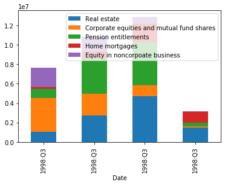

```python
q3_1998_sel.plot(kind='bar', stacked=True);
```

```python
real_estate = q3_1998_sel['Real estate'].to_numpy()
corp_eq = q3_1998_sel['Corporate equities and mutual fund shares'].to_numpy()
pension = q3_1998_sel['Pension entitlements'].to_numpy()
home_morg = q3_1998_sel['Home mortgages'].to_numpy()
private_business = q3_1998_sel['Equity in noncorpoate business'].to_numpy()

print(real_estate)
print(corp_eq)
print(pension)
print(home_morg)
print(private_business)
```

```
[1062140 2701200 4701511 1504406]
[3501698 2295028 1118054   93733]
[ 888699 3555660 4446008  412358]
[ 189955  787706 1900533 1086646]
[1993522 1444382  709518   96460]
```

```python
q3_1998_1 = q3_1998_sel.loc[q3_1998_sel['Category']=='Top1'].iloc[:,1:]
q3_1998_9 = q3_1998_sel.loc[q3_1998_sel["Category"]=='Next9'].iloc[:,1:]
q3_1998_40 = q3_1998_sel.loc[q3_1998_sel["Category"]=='Next40'].iloc[:,1:]
q3_1998_50 = q3_1998_sel.loc[q3_1998_sel["Category"]=='Bottom50'].iloc[:,1:]

print(q3_1998_1.to_numpy())
print(q3_1998_9.to_numpy())
print(q3_1998_40.to_numpy())
print(q3_1998_50.to_numpy())
```

```
[[1062140 3501698  888699  189955 1993522]]
[[2701200 2295028 3555660  787706 1444382]]
[[4701511 1118054 4446008 1900533  709518]]
[[1504406   93733  412358 1086646   96460]]
```

[figure not shown]

```python
N = 4
re = real_estate
ce = corp_eq
p = pension
hm = home_morg
pb = private_business

ind = np.arange(N)    # the x locations for the groups
width = 0.35       # the width of the bars: can also be len(x) sequence

p1 = plt.bar(ind, re, width)
p2 = plt.bar(ind, ce, width, bottom=re)
p3 = plt.bar(ind, p, width, bottom=ce)
p4 = plt.bar(ind, hm, width, bottom=p)
p5 = plt.bar(ind, pb, width, bottom=hm)

plt.ylabel('Dollars - Millions')
plt.title('Net worth Levels - 1998:Q3')
plt.xticks(ind, ('Top 1%', 'Next 5%', 'Next 40%', 'Bottom 50%'))
plt.yticks(np.arange(0, 6000000, 1000000))
plt.legend((p1[0], p2[0], p3[0], p4[0], p5[0]), ('real estate', 'corporate equities', 'pension entitlements', 'home mortgages', 'private businesses'))

plt.show()
```

```python
from bokeh.models import ColumnDataSource
from bokeh.plotting import figure, output_notebook, show

output_notebook()
#y = networth_levels.index.to_numpy()
#x1 = networth_levels.

source = ColumnDataSource(data=dict(
    y=[1, 2, 3, 4, 5],
    x1=[1, 2, 4, 3, 4],
    x2=[1, 4, 2, 2, 3],
))
p = figure(plot_width=400, plot_height=400)

p.vbar_stack(['x1', 'x2'], x=10, width=0.9, color=("grey", "lightgrey"), source=source)

show(p)
```

[interactive chart not shown]